# Challenge 7

Author

Giovanni Librizzi

# Revision

In browsing the R functions to find a way to set values as NA I found replace, but I totally forgot about the vectorised if/case_when functions that we could use for this exact situation! I made sure to replace it with a case when, which will automatically set it to NA if the condition isn’t met. When setting the condition index, I nested the condition index function inside the na setting function, which can make things unclear to the reader. I modified that chunk of code to run one function at a time, so it can be much clearer to the reader and easier to modify. I also accidentally kept a years variable in from when I was testing to see if it would work, so I made sure to remove that. Additionally, I changed the boxplots in the final graph to density plots and changed their colors to make it a lot more clear. I also included an explanation for why I modified the units like I did.

### Setup

```r
library(tidyverse)
library(ggridges)
library(RColorBrewer)

# import surveys
recapture_data <- read_csv(here::here("Week7", "Lab", "BlackfootFish.csv"))
recapture_data <- recapture_data |>
  mutate(across(
    c(trip, section, species),
    ~ as.factor(.x)
  ))
```

```r
recapture_data |>
  filter(species == "RBT") |>
  summarize(
    avg_length = median(length),
    avg_weight = median(weight, na.rm = TRUE)
    )
```

```
# A tibble: 1 × 2
  avg_length avg_weight
       <dbl>      <dbl>
1        223        110
```

```r
recapture_data <- recapture_data |>
  mutate(length = length / 10)
```

Convert to a length unit that is compatible with the current condition index formula. I divided it by 10 because that caused the condition index to be a lot more centered around 1, making it seem like that’s the proper units required by the formula.

# 4.1 Part 1 - Replace Impossible Measurements with `NA`s

```r
# set values NA for a vector
na_not_between <- function(measurements, min_val, max_val) {
  stopifnot(is.numeric(measurements), length(measurements) >= 1)

  result <- case_when(
      between(measurements, min_val, max_val) ~ measurements
    )



  return(result)
}


# Apply to the data
recapture_cut <- recapture_data |>
  mutate(
    length = na_not_between(
      measurements = length,
      min_val = 2.5,
      max_val = 77.5),
    weight = na_not_between(
      measurements = weight,
      min_val = 0.9,
      max_val = 200)
  )
```

# 4.2 Part 2

```r
# calculate the condition index of a fish
condition_index <- function(weight, length) {

    result <- (weight / (length^3)) * 100
    return(result)

}

# Create a new condition index column with restraints
recapture_cut <- recapture_cut |>
  mutate(
    condition_index = condition_index(weight, length),
    condition_index = na_not_between(
      measurements = condition_index,
      min_val = 0,
      max_val = 5
    )
  )
```

# 4.3 Part 3

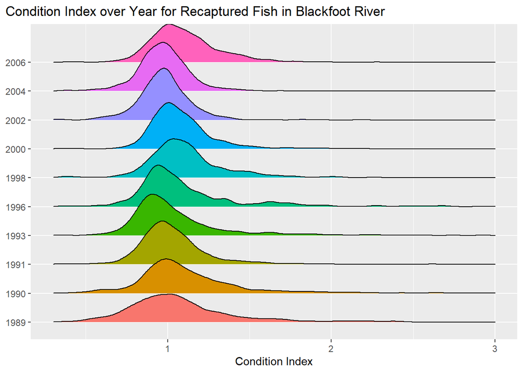

```r
recapture_cut |>
  ggplot(mapping = aes(x = condition_index, y = factor(year))) +
  geom_density_ridges(mapping = aes(fill = factor(year))) +
  scale_colour_brewer(palette = "RdYlBu") +
  xlim(0.3, 3) +
  labs(
    x = "Condition Index",
    y = NULL,
    title = "Condition Index over Year for Recaptured Fish in Blackfoot River",
    color = "Section"
  ) +
  theme(
    plot.title.position = "plot",
    legend.position="none"
  )
```

Fish conditions appear to have stayed relatively the same around the condition index. There were a lot more outliers in the past, but 2004 seems to be very close to 1 with not many outliers.

xlim: https://ggplot2.tidyverse.org/reference/lims.html